# hw2_Sun

Xiaozhong Sun

3/12/2018

```r
library(tibble)
library(tidyr)
library(purrr)
library(dplyr)
```

```r
library(ggplot2)
library(texreg)
library(stargazer)
library(readr)
```

```r
sprinters <- read_csv("sprinters.csv")
sprinters$ones <- 1
X <- as.matrix(sprinters[,c(4,1,3)])
y <- as.matrix(sprinters[,2])
b<- solve(t(X)%*% X)%*% t(X)%*%y
b
```

```
##            finish
## ones  34.96003685
## year  -0.01260896
## women  1.09281183
```

```r
fin <- lm(finish ~ year+women, data = sprinters)
summary(fin)
```

```
##
## Call:
## lm(formula = finish ~ year + women, data = sprinters)
##
## Residuals:
##      Min       1Q   Median       3Q      Max
## -0.44623 -0.10170  0.02093  0.11094  0.45724
##
## Coefficients:
##              Estimate Std. Error t value Pr(>|t|)
## (Intercept) 34.960037   1.964903   17.79  < 2e-16 ***
## year        -0.012609   0.001005  -12.54 2.89e-15 ***
## women        1.092812   0.059502   18.37  < 2e-16 ***
## ---
## Signif. codes:  0 '***' 0.001 '**' 0.01 '*' 0.05 '.' 0.1 ' ' 1
##
## Residual standard error: 0.1852 on 39 degrees of freedom
## Multiple R-squared:  0.9125, Adjusted R-squared:  0.9081
## F-statistic: 203.5 on 2 and 39 DF,  p-value: < 2.2e-16
```

*The results are the same, they are the coefficients of each term.*

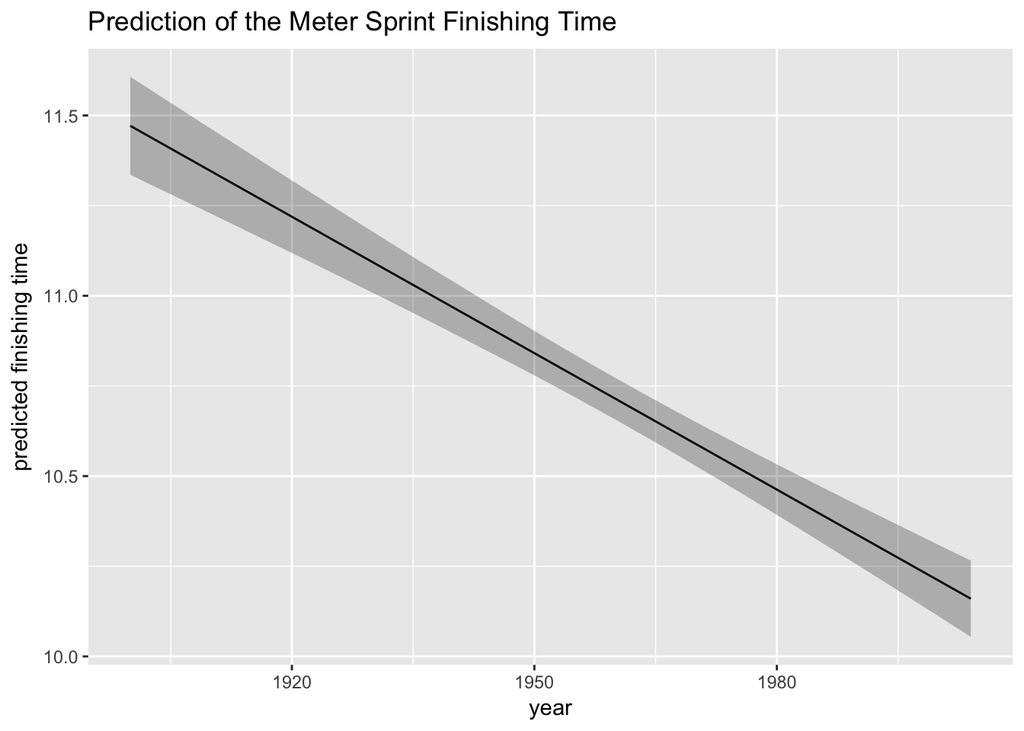

```r
xhyp <- data.frame(year = sprinters$year, women = mean(sprinters$women))
preds <- predict(fin, newdata = xhyp , interval = "confidence")
pred_plot <- cbind(preds, xhyp)
p1<-ggplot(pred_plot, aes(x = year, y = fit, ymin = lwr, ymax =  upr)) +
  geom_line() +
  geom_ribbon(alpha = .3)
p1 + ggtitle("Prediction of the Meter Sprint Finishing Time") +
  xlab("year") + ylab("predicted finishing time")
```

```r
fin_interact <- lm(finish ~ year*women, data = sprinters)
summary(fin_interact)
```

```
##
## Call:
## lm(formula = finish ~ year * women, data = sprinters)
##
## Residuals:
##      Min       1Q   Median       3Q      Max
## -0.37579 -0.05460  0.00738  0.08276  0.32234
##
## Coefficients:
##              Estimate Std. Error t value Pr(>|t|)
## (Intercept) 31.826453   2.128910  14.950  < 2e-16 ***
## year        -0.011006   0.001089 -10.104 2.56e-12 ***
## women       12.520596   4.076141   3.072  0.00392 **
## year:women  -0.005817   0.002074  -2.804  0.00791 **
## ---
## Signif. codes:  0 '***' 0.001 '**' 0.01 '*' 0.05 '.' 0.1 ' ' 1
##
## Residual standard error: 0.1707 on 38 degrees of freedom
## Multiple R-squared:  0.9275, Adjusted R-squared:  0.9218
## F-statistic: 162.1 on 3 and 38 DF,  p-value: < 2.2e-16
```

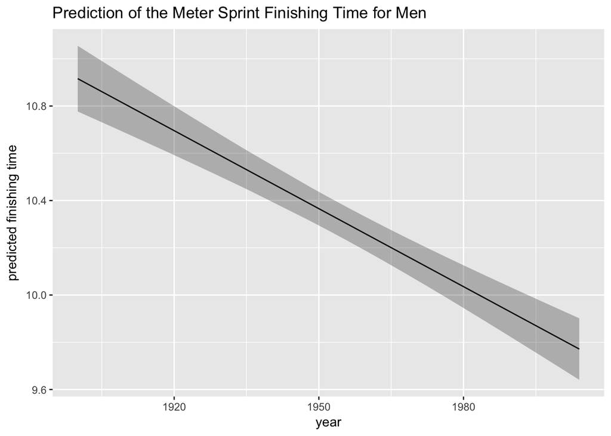

```r
xhyp1 <-data.frame(year = sprinters$year,women = 0)
xhyp2 <-data.frame(year = sprinters$year,women = 1)
pred_interact1 <- predict(fin_interact, newdata = xhyp1  , interval = "confidence")
pred_interact2 <- predict(fin_interact, newdata = xhyp2  , interval = "confidence")
pred_plot1 <- cbind(pred_interact1, xhyp1)
pred_plot2 <- cbind(pred_interact2, xhyp2)
p2<-ggplot(pred_plot1, aes(x = year, y = fit, ymin = lwr, ymax =  upr)) +
  geom_line() +
  geom_ribbon(alpha = .3)
p2 + ggtitle("Prediction of the Meter Sprint Finishing Time for Men") +
  xlab("year") + ylab("predicted finishing time")
```

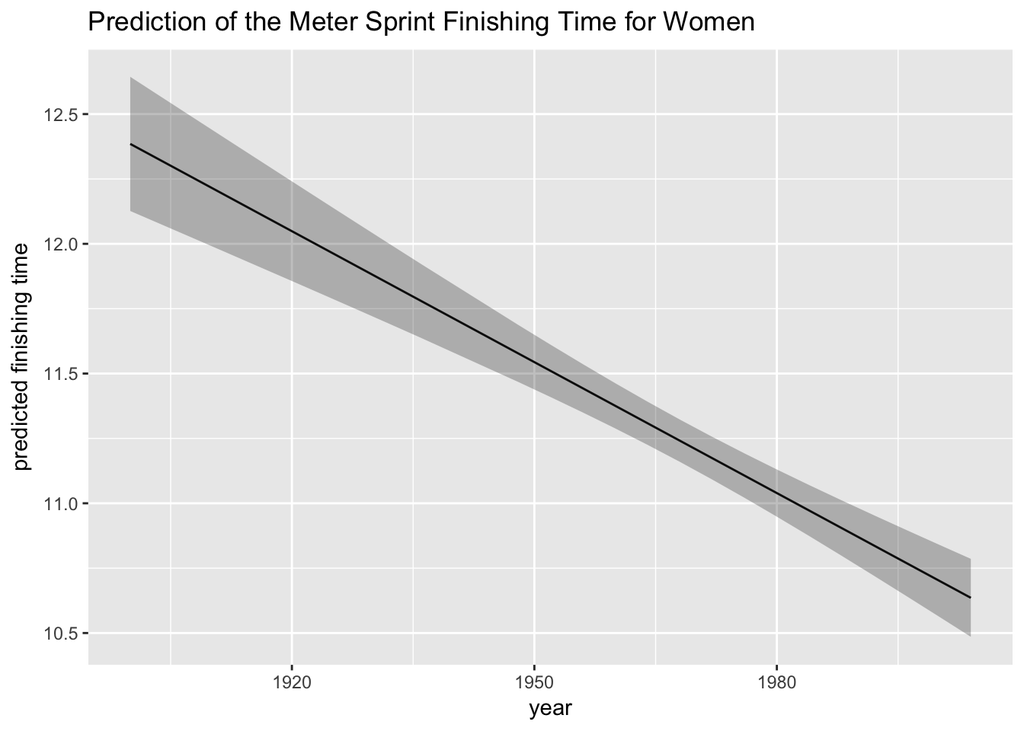

```r
p3<-ggplot(pred_plot2, aes(x = year, y = fit, ymin = lwr, ymax =  upr)) +
  geom_line() +
  geom_ribbon(alpha = .3)
p3 + ggtitle("Prediction of the Meter Sprint Finishing Time for Women") +
  xlab("year") + ylab("predicted finishing time")
```

```r
prewomen<-data_frame(year = 2001, women = 1)
premen<-data_frame(year= 2001, women=0)
predict(fin, newdata  = prewomen,interval = "confidence")
```

```
##        fit      lwr      upr
## 1 10.82231 10.71225 10.93237
```

```r
predict(fin, newdata  = premen,interval = "confidence")
```

```
##        fit     lwr      upr
## 1 9.729498 9.60765 9.851347
```

```r
predict(fin, newdata  = data_frame(year=2156, women = 1),interval = "confidence")
```

```
##        fit     lwr      upr
## 1 8.867921 8.47693 9.258911
```

```r
predict(fin, newdata  = data_frame(year=2156, women = 0),interval = "confidence")
```

```
##        fit      lwr      upr
## 1 7.775109 7.358004 8.192213
```

```r
predict(fin, newdata  = data_frame(year=3000, women = 1),interval = "confidence")
```

```
##         fit       lwr       upr
## 1 -1.774046 -3.872865 0.3247739
```

```r
predict(fin, newdata  = data_frame(year=3000, women = 0),interval = "confidence")
```

```
##         fit       lwr        upr
## 1 -2.866858 -4.994337 -0.7393778
```

*Based on the prediction of year 3000, we can see that the finishing time become negative, which is impossible for human species (maybe technology is advanced enough for us to run back to the past, or time travel). Therefore, the assumption that finshing time is a linear model of year and gender is questionable. With time goes on, the results become less accurate and thus I don’t trust the result of 2156.*

```r
data("anscombe")
anscombeclean <- anscombe %>%
    mutate(obs = row_number()) %>%
    gather(variable_dataset, value, - obs) %>%
    separate(variable_dataset, c("variable", "dataset"), sep = 1L) %>%
    spread(variable, value) %>%
    arrange(dataset, obs)
```

```r
anscombeclean %>% group_by(dataset) %>% select(x)%>%summarise_each(funs(mean, sd))
```

```
## `summarise_each()` is deprecated.
## Use `summarise_all()`, `summarise_at()` or `summarise_if()` instead.
## To map `funs` over all variables, use `summarise_all()`
```

```
## # A tibble: 4 x 3
##   dataset  mean       sd
##     <chr> <dbl>    <dbl>
## 1       1     9 3.316625
## 2       2     9 3.316625
## 3       3     9 3.316625
## 4       4     9 3.316625
```

```r
anscombeclean %>% group_by(dataset) %>% select(y)%>%summarise_each(funs(mean, sd))
```

```
## `summarise_each()` is deprecated.
## Use `summarise_all()`, `summarise_at()` or `summarise_if()` instead.
## To map `funs` over all variables, use `summarise_all()`
```

```
## # A tibble: 4 x 3
##   dataset     mean       sd
##     <chr>    <dbl>    <dbl>
## 1       1 7.500909 2.031568
## 2       2 7.500909 2.031657
## 3       3 7.500000 2.030424
## 4       4 7.500909 2.030579
```

```r
cor(anscombeclean[c(1:11),c(3:4)], use="pairwise", method="spearman")
```

```
##           x         y
## x 1.0000000 0.8181818
## y 0.8181818 1.0000000
```

```r
cor(anscombeclean[c(12:22),c(3:4)], use="pairwise", method="spearman")
```

```
##           x         y
## x 1.0000000 0.6909091
## y 0.6909091 1.0000000
```

```r
cor(anscombeclean[c(13:33),c(3:4)], use="pairwise", method="spearman")
```

```
##           x         y
## x 1.0000000 0.8729688
## y 0.8729688 1.0000000
```

```r
cor(anscombeclean[c(14:44),c(3:4)], use="pairwise", method="spearman")
```

```
##          x        y
## x 1.000000 0.810854
## y 0.810854 1.000000
```

```r
lm1<-lm(y ~ x, data=subset(anscombeclean, dataset=="1"))
lm2<-lm(y ~ x, data=subset(anscombeclean, dataset=="2"))
lm3<-lm(y ~ x, data=subset(anscombeclean, dataset=="3"))
lm4<-lm(y ~ x, data=subset(anscombeclean, dataset=="4"))
```

```r
summary(lm1)$r.squared
```

```
## [1] 0.6665425
```

```r
summary(lm2)$r.squared
```

```
## [1] 0.666242
```

```r
summary(lm3)$r.squared
```

```
## [1] 0.666324
```

```r
summary(lm4)$r.squared
```

```
## [1] 0.6667073
```

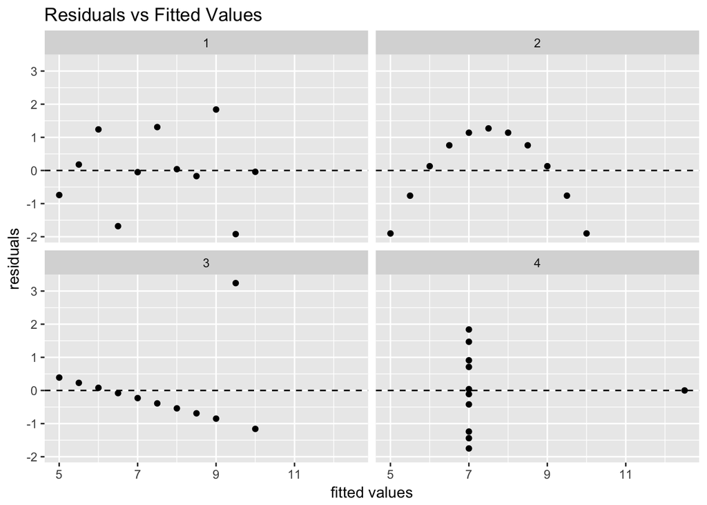

```r
#?? How to add r^2 and regression line into plot
lm<-lm(y~x,data=anscombeclean)
residuals_lm <- lm$residuals
fitted_lm <- lm$fitted.values
res_pre<-cbind(residuals_lm,fitted_lm,anscombeclean)
p4<-ggplot(res_pre, aes(fitted_lm, residuals_lm)) +geom_abline(intercept = 0, slope = 0,linetype="dashed")+
  geom_point() +facet_wrap(~ dataset)
p4+ggtitle("Residuals vs Fitted Values") +
  xlab("fitted values") + ylab("residuals")
```

## Research Project

The theory of decentralization indicates strategic interactions among local jurisdictions. Compete for limited mobile capital and human resources and achieving development goals, local governments implement fiscal, environmental, labor regulatory, and trade policies partly depending on their rival jurisdictions. In the real world, these strategic policy interactions could lead to regional divergence due to competitive edge endowed by different regions. For instance, empirical evidence finds that fiscal decentralization tends to increase regional disparities in developing countries and reduces them in developed countries. In light of this, some scholars propose that the effects of fiscal decentralization on regional disparities might be influenced by the embedded quality of institutional settings. The concerns for uneven regional development and urban stratification raise the research questions for this study: What factors influence the effects of inter-jurisdictional competitions on the degree of regional disparities? What is the role of government quality in influencing the effects of inter-jurisdictional competitions on the degree of regional disparities? Will higher government quality mitigate the effect of inter-jurisdictional competitions on the degree of regional disparities? Based on my research questions, this study identifies three key variables that need to be defined and constructed: dependent variable measuring the degree of regional disparities, an independent variable measuring the type and intensity of regional competitions, and an independent variable measuring the quality of government My study is based on China. Right now, I have the data of GDP, income, population, Foreign Direct Investment, and other regional characteristics at prefectural-city level from 31 provincial statistic year books from 2007 to 2017. The data that are still missing are detailed government expenditures on education, environmental protection, and health insurance. These data are used to construct variable measuring government quality.